# Informe PISA

Daniel Corral Ruiz

09-11-2020

### Introducción

El conjunto de datos se ha construido utilizando la puntuación media en Ciencias por país del Programa para la Evaluación Internacional de Estudiantes (PISA) 2006, junto con el GNI per cápita (paridad del poder adquisitivo, dólares de 2005), el índice educativo, el índice de salud y el índice de desarrollo humano de la ONU (HDI).

### Variables estudiadas

Las variables clave son las siguientes:

- Overall Science Score (average score for 15 year olds): Puntuación global en ciencias (puntuación media para los jóvenes de 15 años)
- Interest in science: El interés en la ciencia
- Support for scientific inquiry: Apoyo a la investigación científica
- Income Index: Índice de ingresos
- Health Index: Índice de salud
- Education Index: Índice de educación
- Human Development Index (composed of the Income index, Health Index, and Education Index): Índice de Desarrollo Humano (compuesto por el índice de ingresos, el índice de salud y el índice de educación)

### Carga de datos

```r
mData=read.csv("pisasci2006.csv")
mData = na_mean(mData)
head(mData)
```

|  | Country | Overall | Issues | Explain | Evidence | Interest | Support | Income | Health | Edu | HDI |
| --- | --- | --- | --- | --- | --- | --- | --- | --- | --- | --- | --- |
| 1 | Albania | 473.1404 | 469.9123 | 475.0175 | 469.807 | 528.1579 | 512.1754 | 0.599 | 0.886 | 0.716000 | 0.7240000 |
| 2 | Argentina | 391.0000 | 395.0000 | 386.0000 | 385.000 | 567.0000 | 506.0000 | 0.678 | 0.868 | 0.786000 | 0.7730000 |
| 3 | Australia | 527.0000 | 535.0000 | 520.0000 | 531.000 | 465.0000 | 487.0000 | 0.826 | 0.965 | 0.978000 | 0.9200000 |
| 4 | Austria | 511.0000 | 505.0000 | 516.0000 | 505.000 | 507.0000 | 515.0000 | 0.835 | 0.944 | 0.824000 | 0.8660000 |
| 5 | Azerbaijan | 382.0000 | 353.0000 | 412.0000 | 344.000 | 612.0000 | 542.0000 | 0.566 | 0.780 | 0.799322 | 0.8060169 |
| 6 | Belgium | 510.0000 | 515.0000 | 503.0000 | 516.000 | 503.0000 | 492.0000 | 0.831 | 0.935 | 0.868000 | 0.8770000 |

Mediante la funcion “na_mean” sustituimos cada valor NA por el valor de la media de la variable.

### Representación gráfica

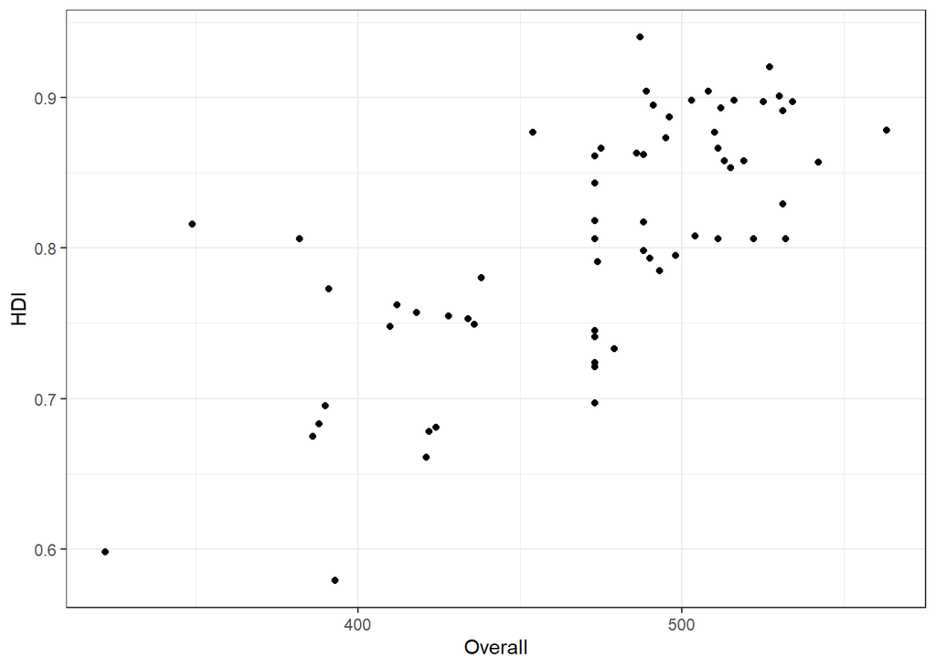

```r
ggplot(data = mData, mapping = aes(x = Overall, y = HDI)) +
  layer(geom = "point",stat = "identity",position = "identity") +
  theme_bw() + theme(legend.key = element_blank())
```

```r
skim(mData)
```

Data summary

| Name | mData |
| --- | --- |
| Number of rows | 65 |
| Number of columns | 11 |
| _______________________ |  |
| Column type frequency: |  |
| character | 1 |
| numeric | 10 |
| ________________________ |  |
| Group variables | None |

**Variable type: character**

| skim_variable | n_missing | complete_rate | min | max | empty | n_unique | whitespace |
| --- | --- | --- | --- | --- | --- | --- | --- |
| Country | 0 | 1 | 4 | 24 | 0 | 65 | 0 |

**Variable type: numeric**

| skim_variable | n_missing | complete_rate | mean | sd | p0 | p25 | p50 | p75 | p100 | hist |
| --- | --- | --- | --- | --- | --- | --- | --- | --- | --- | --- |
| Overall | 0 | 1 | 473.14 | 51.06 | 322.00 | 436.00 | 487.00 | 511.00 | 563.00 | ▁▂▂▇▃ |
| Issues | 0 | 1 | 469.91 | 50.44 | 321.00 | 431.00 | 483.00 | 509.00 | 555.00 | ▁▂▂▇▅ |
| Explain | 0 | 1 | 475.02 | 50.53 | 334.00 | 441.00 | 483.00 | 516.00 | 566.00 | ▁▂▂▇▃ |
| Evidence | 0 | 1 | 469.81 | 57.75 | 288.00 | 429.00 | 481.00 | 512.00 | 567.00 | ▁▂▂▇▅ |
| Interest | 0 | 1 | 528.16 | 46.62 | 448.00 | 503.00 | 528.16 | 549.00 | 644.00 | ▆▇▇▃▂ |
| Support | 0 | 1 | 512.18 | 24.40 | 447.00 | 497.00 | 512.18 | 527.00 | 569.00 | ▂▃▇▅▂ |
| Income | 0 | 1 | 0.74 | 0.11 | 0.41 | 0.66 | 0.74 | 0.83 | 0.94 | ▁▂▆▇▅ |
| Health | 0 | 1 | 0.89 | 0.06 | 0.72 | 0.84 | 0.89 | 0.94 | 0.99 | ▂▂▇▇▇ |
| Edu | 0 | 1 | 0.80 | 0.11 | 0.54 | 0.74 | 0.80 | 0.87 | 0.99 | ▂▃▇▇▅ |
| HDI | 0 | 1 | 0.81 | 0.08 | 0.58 | 0.75 | 0.81 | 0.87 | 0.94 | ▁▃▆▇▆ |

### Observar los grados de libertad

```r
# SPLINES HEALTH
splhealth <- smooth.spline(x = mData$Health, y = mData$Overall, cv = TRUE)
splhealth$df
```

```
## [1] 2.002844
```

```r
# SPLINES EDU
spledu <- smooth.spline(x = mData$Edu, y = mData$Overall, cv = TRUE)
spledu$df
```

```
## [1] 2.002385
```

```r
# SPLINES HDI
splhdi <- smooth.spline(x = mData$HDI, y = mData$Overall, cv = TRUE)
splhdi$df
```

```
## [1] 8.603228
```

```r
# SPLINES INTEREST
splinterest <- smooth.spline(x = mData$Interest, y = mData$Overall, cv = TRUE)
splinterest$df
```

```
## [1] 4.750171
```

```r
# SPLINES SUPPORT
splsupport <- smooth.spline(x = mData$Support, y = mData$Overall, cv = TRUE)
splsupport$df
```

```
## [1] 2.001243
```

```r
# SPLINES INCOME
splincome <- smooth.spline(x = mData$Income, y = mData$Overall, cv = TRUE)
splincome$df
```

```
## [1] 4.244952
```

### Comparación de modelos

Modelo con todo splines:

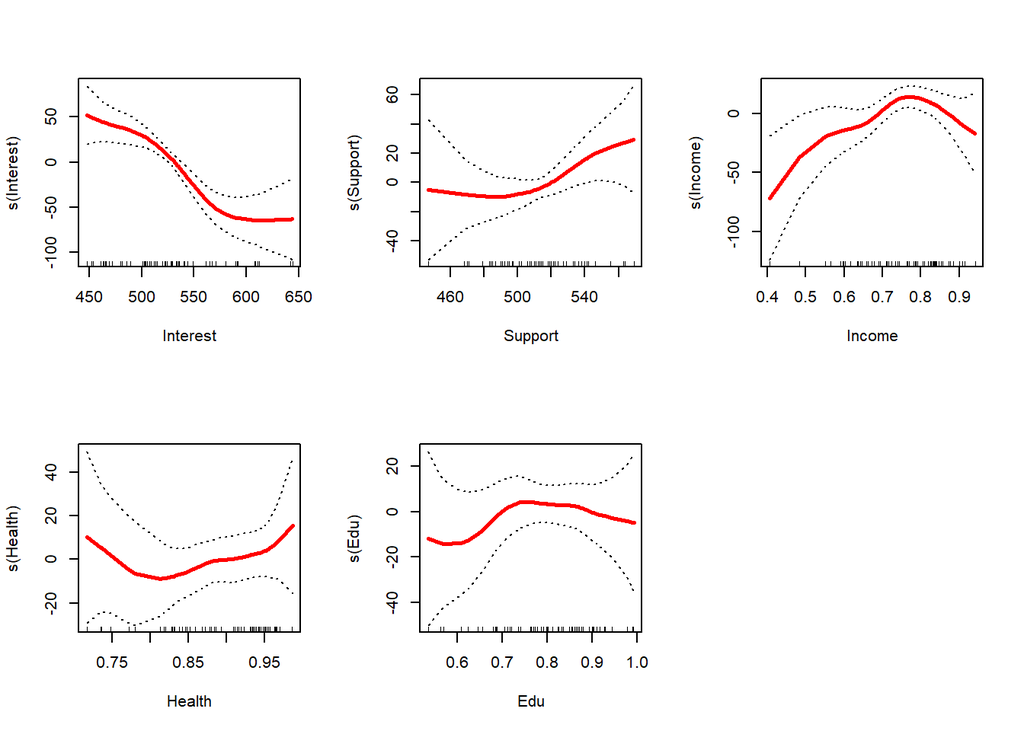

```r
splinemodel <- gam(Overall ~ s(Interest) + s(Support) + s(Income) + s(Health) + s(Edu), data = mData)
par(mfrow = c(2, 3))
plot(splinemodel, se = TRUE, col = 'red', lwd = 2.5)
```

Segundo modelo:

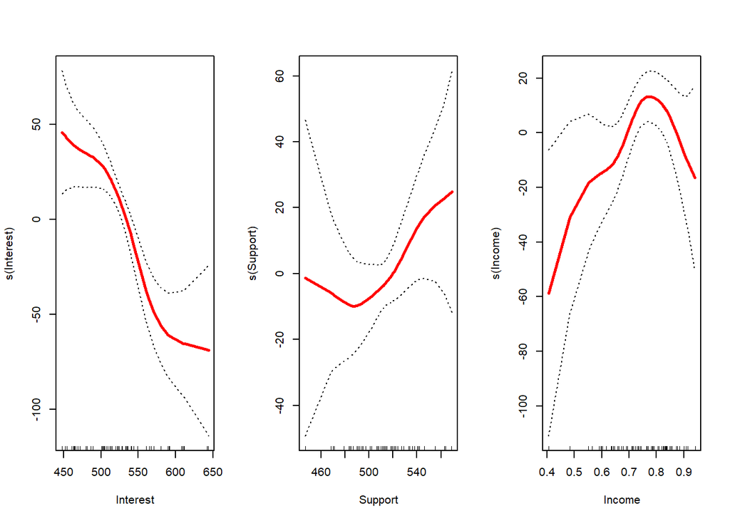

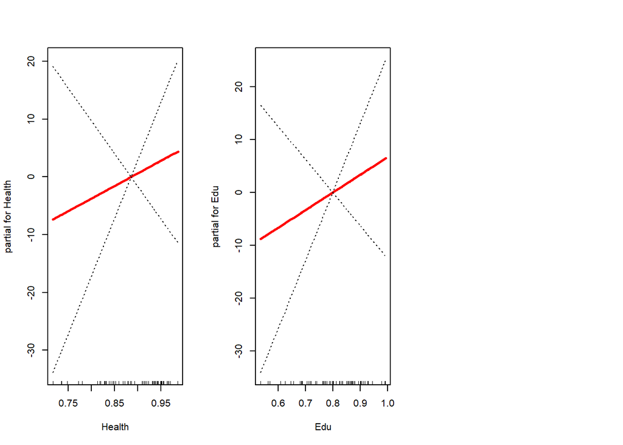

```r
splinemodel2 <- gam(Overall ~ s(Interest) + s(Support) + s(Income) + Health + Edu, data = mData)
par(mfrow = c(1, 3))
plot(splinemodel2, se = TRUE, col = 'red', lwd = 2.5)
```

### Comparamos modelos

```r
anova(splinemodel,splinemodel2,test='F')
```

|  | Resid. Df | Resid. Dev | Df | Deviance | F | Pr(>F) |
| --- | --- | --- | --- | --- | --- | --- |
| 1 | 44.00011 | 28490.78 | NA | NA | NA | NA |
| 2 | 50.00027 | 32341.03 | -6.000156 | -3850.245 | 0.9910036 | 0.4431591 |

Modelo 2 > Modelo 1

Resumen del modelo:

```r
summary(splinemodel2)
```

```
##
## Call: gam(formula = Overall ~ s(Interest) + s(Support) + s(Income) +
##     Health + Edu, data = mData)
## Deviance Residuals:
##     Min      1Q  Median      3Q     Max
## -66.852 -13.049  -0.784  14.469  58.421
##
## (Dispersion Parameter for gaussian family taken to be 646.8171)
##
##     Null Deviance: 166828.9 on 64 degrees of freedom
## Residual Deviance: 32341.03 on 50.0003 degrees of freedom
## AIC: 620.0923
##
## Number of Local Scoring Iterations: NA
##
## Anova for Parametric Effects
##             Df Sum Sq Mean Sq  F value  Pr(>F)
## s(Interest)  1  95163   95163 147.1258 < 2e-16 ***
## s(Support)   1   2626    2626   4.0600 0.04930 *
## s(Income)    1   4162    4162   6.4343 0.01436 *
## Health       1    310     310   0.4790 0.49209
## Edu          1    314     314   0.4855 0.48915
## Residuals   50  32341     647
## ---
## Signif. codes:  0 '***' 0.001 '**' 0.01 '*' 0.05 '.' 0.1 ' ' 1
##
## Anova for Nonparametric Effects
##             Npar Df Npar F    Pr(F)
## (Intercept)
## s(Interest)       3 4.6725 0.005917 **
## s(Support)        3 0.8938 0.450895
## s(Income)         3 4.3404 0.008544 **
## Health
## Edu
## ---
## Signif. codes:  0 '***' 0.001 '**' 0.01 '*' 0.05 '.' 0.1 ' ' 1
```